## Data Set Summary:

The data set Credit Approval is used in credit risk analysis to develop models that can accurately predict credit card approval or denial based on the applicant’s characteristics and financial history. The data set is also used to evaluate the performance of various predictive models and to identify factors that are the most predictive of credit approval.There are a total of 690 observations in the data set.

The data set contains the following variables: A1: Categorical variable Gender (0, 1). A2: Numerical variable Age. A3: Numerical variable Debt. A4: Categorical variable indicating Marital Status (0,1). A5: Categorical variable Bank Customer (0,1). A6: Categorical variable Occupation. A7: Categorical variable Indicating Ethnicity. A8: Numerical variable Years Employed. A9: Categorical variable Prior Default (0,1) A10: Categorical variable Employed (0,1) A11: Numerical variable Credit Score. A12: Categorical variable Drivers License. A13: Categorical variable Citizenship. A14: Numerical variable Zip Code. A15: Numerical variable Income. A16: Binary response variable indicating whether the credit card application was Approved (0,1).

## Research Question:

Can a multiple logistic regression model be used to predict whether a credit card application will be approved or not, based on the applicant’s demographic and financial information?

## Exploratory Analysis:

First pairwise scatter plots are created to find potential issues with normality in numerical predictor variables. All four of the scatter plots show issues, so a closer look is needed.

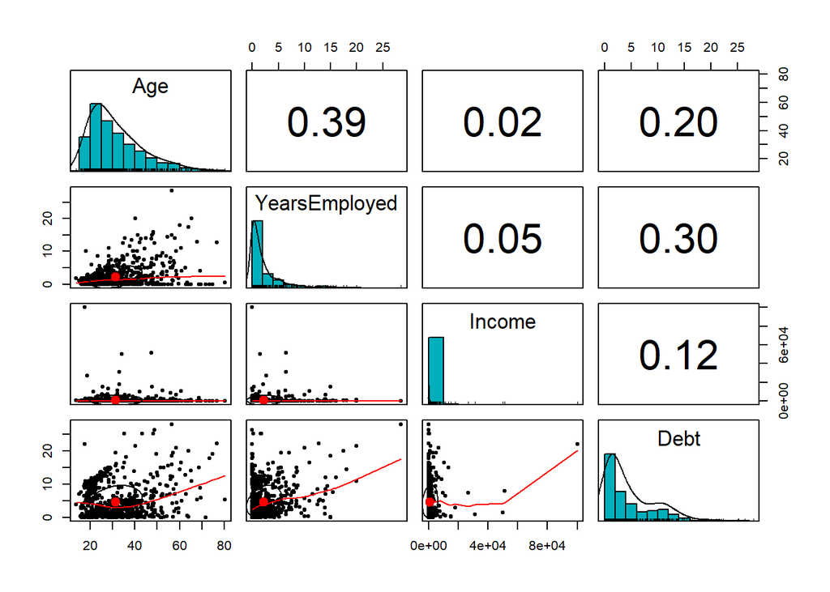

Because there appears to be issues with the scatter plots, histograms are created for each of the variables. Age, YearsEmployed, and Debt, all show varying amounts of skewness, whereas Income seems to be suffering from a grouping problem.

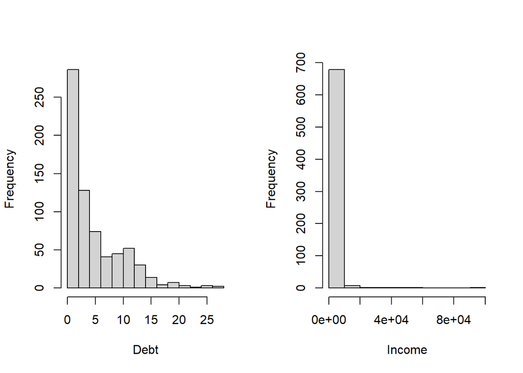

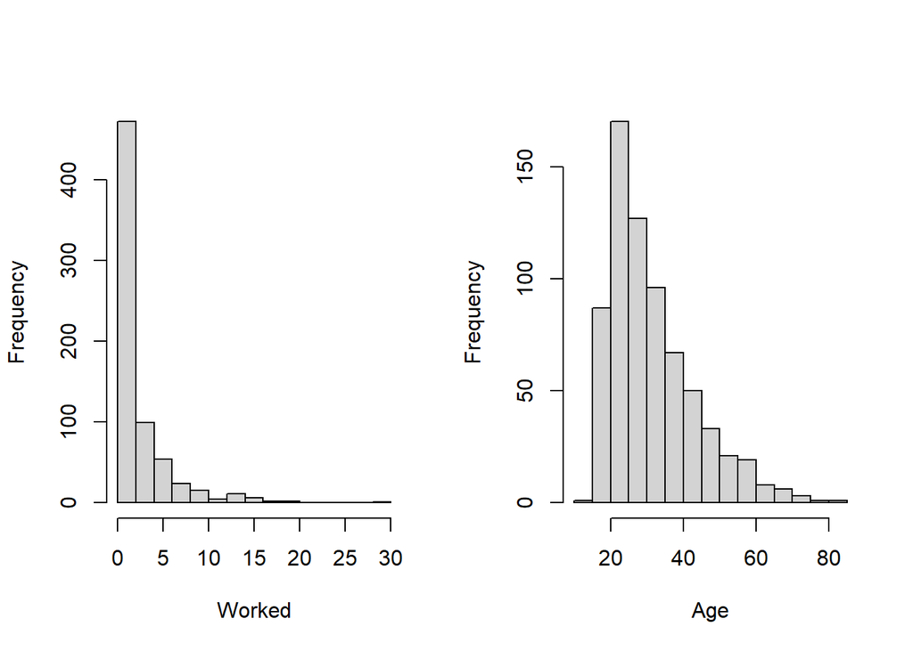

To fix the issues with the histograms, the cut function is used to group the variables. This will help normalize the histograms distributions.